# Practical Machine Learning: Weight Lifting Exercise

F. Garcia

Sunday, August 24, 2015

# Overview

The goal of this article is to determine whether a user is performing properly a weight lifting exercise. For that purpose the user movements are tracked via sensors and the user will be indicated whether the exercise has been correct (A) or there were some common mistakes present (B, C, D, E). The data has been gathered by Velloso, E.; Bulling, A.; Gellersen, H.; Ugulino, W.; Fuks, H. in Qualitative Activity Recognition of Weight Lifting Exercises

# Data Loading

The data set has been obtained from:

Read more: http://groupware.les.inf.puc-rio.br/har#ixzz3jgAWTs2a

# Exploratory Analysis

The data set is divided in the following sections: - X: observation number - user_name: User that performed the exercise - time/date: information on the timestamp of the measurement - belt features - arm features - dumbbell features - forearm features - classe: factor that determines whether the exercise is right (A) or is wrong (B,C,D,E)

# Partition the data

As the entries for every user are equally distributed, and we have enough information we will use 60% for training, 40% for testing.

```r
# Create training and testing data sets
library(caret)
inTrain <- createDataPartition(pml.training$classe, p = 0.6, list=FALSE)
training <- pml.training[inTrain,]
testing <- pml.training[-inTrain,]

# Reproducible Research requires setting a seed
set.seed(7)

# Separate the variables and the outcome
train_out <- training[,160]
training <- training[,-160]

test_out <- testing[,160]
testing <- testing[,-160]
```

# Clean the data

It can be seen that many variables have more than 95% of NAs. These variables will be discarded. We will discard the time variables as we will not do any time prediction, and the variables *X* and *user_name*, because both of them contain values that are unique to the training set. New values, will not have the same time or user name.

```r
# Remove variables with more than 50% of NAs
na.percentage <- apply(training, 2, function(x) { sum(is.na(x))/nrow(training) })
isValid <- na.percentage < 0.5
training <- subset(training, select = isValid)

# Remove time and variables specific to the training set
training <- subset(training, select=c(-X, -user_name, -raw_timestamp_part_1, -raw_timestamp_part_2, -cvtd_timestamp, -new_window, -num_window))
```

# Preprocessing

## Near Zero Variance values

Search for the Near Zero Values and eliminate them as they will be bad predictors. There are no NZV values present in the current list of variables.

```r
# Remove Near Zero Variance Variables
nzvs <- nearZeroVar(training)
if (length(nzvs))
{
        training <- subset(training, select = -nzvs)
}
```

## Identifying Correlated Predictors

There are 7 variables that are correlated on more than 90% with other variables. We can remove them.

```r
descrCor <- cor(training)
correlatedVars <- findCorrelation(descrCor)
if (length(descrCor))
{
        training <- subset(training, select = -correlatedVars)
}

correlatedVars
```

```
## [1] 10  1  9  8 19 46 31
```

## Find Linear Combos

No variables are a linear combination of other variables.

```r
lcomboVars <- findLinearCombos(training)
if (length(lcomboVars$remove))
{
        training <- subset(training, select = -lcomboVars$remove)
}
```

## Center and Scaling

Let’s normalize the training data. We will have to normalize as well the testing data.

```r
preProcValuesCS <- preProcess(training, method = c("center","scale"))
training <- predict(preProcValuesCS, training)
```

# Model Selection

As this is a classification problem we will use trees mainly to create the model, but we will compare with QDA model as well. The train funtion in caret allows using the train data set to perform cross-validation of the data and adjust the model. We will take advantage of this feature, but we need to tune the parameters.

## Small subset

Instead of using a big set of data, to compare different models let’s work with a 10th of the training set.

```r
# Use a small sample set
folds <- createFolds(train_out, k=10, list=TRUE, returnTrain=FALSE)
tr <- training[folds$Fold01,]
tr_out <- train_out[folds$Fold01]
```

## Cross-validation

In order to test our model we will not use the default bootstraping method but cross-validation. For that purpose we define a 3-fold to use inside the validation phase of the train method.

```r
tCtrl <- trainControl(method ="cv", number = 3)
```

## QDA

```r
system.time(fitQDA <- train(y = tr_out, x = tr, method="qda", trControl=tCtrl))
```

```
##    user  system elapsed
##    0.56    0.00    0.60
```

```r
fitQDA$results
```

```
##   parameter  Accuracy     Kappa AccuracySD    KappaSD
## 1      none 0.8439355 0.8024566 0.01255186 0.01547725
```

## Gbm

```r
system.time(fitGbm <- train(y = tr_out, x = tr, method="gbm", trControl = tCtrl, verbose=FALSE))
```

```
##    user  system elapsed
##   12.62    0.00   12.63
```

```r
fitGbm$bestTune
```

```
##   n.trees interaction.depth shrinkage n.minobsinnode
## 9     150                 3       0.1             10
```

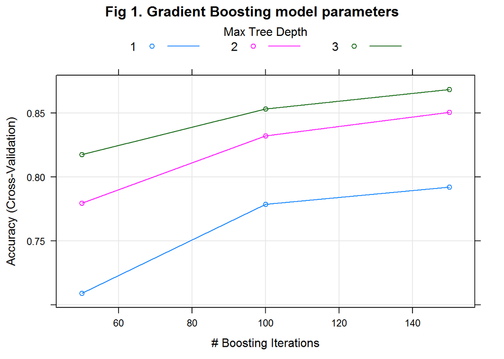

```r
plot(fitGbm, main="Fig 1. Gradient Boosting model parameters")
```

```r
# Set the parameters
gbmGrid <- expand.grid(fitGbm$bestTune)
```

## Random Forest

```r
system.time(fitRF <- train(y = tr_out, x = tr, method="rf", trControl = tCtrl))
```

```
##    user  system elapsed
##   19.68    0.18   19.88
```

```r
fitRF$bestTune
```

```
##   mtry
## 2   23
```

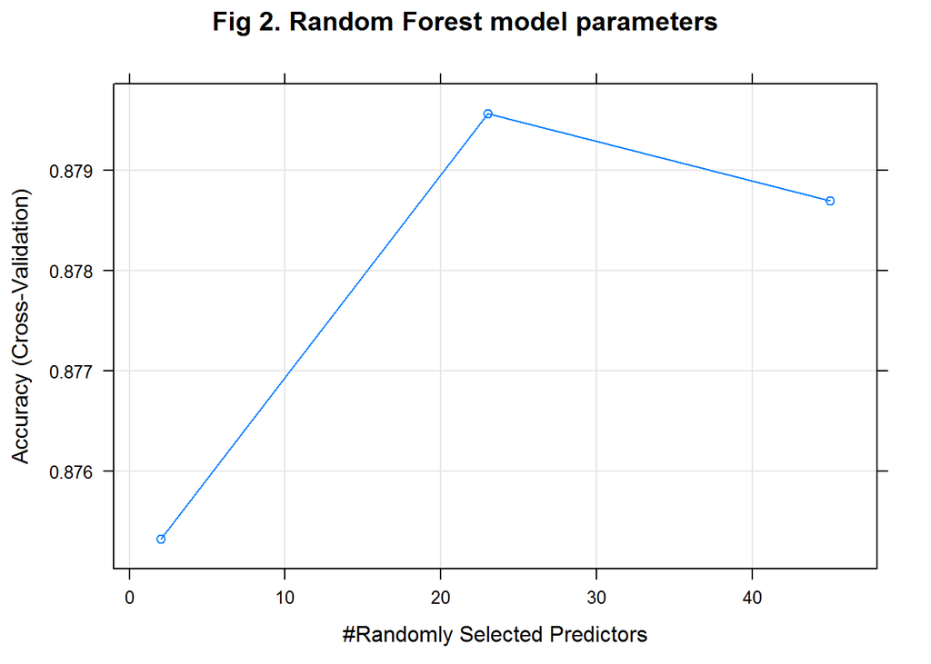

```r
plot(fitRF, main="Fig 2. Random Forest model parameters")
```

```r
# Set the parameters
rfGrid <- expand.grid(fitRF$bestTune)
```

## Final Model

We can compare what is the accuracy of the three selected models. But first we have to train the models with the tuned parameters and the full training data set.

```r
system.time(fitQDAfinal <- train(y = train_out, x = training, method = "qda", trControl = tCtrl))
```

```
##    user  system elapsed
##    1.11    0.06    1.19
```

```r
predQDA <- predict(fitQDAfinal, training)
confusionMatrix(predQDA, train_out)$overall
```

```
##       Accuracy          Kappa  AccuracyLower  AccuracyUpper   AccuracyNull
##   8.823030e-01   8.516337e-01   8.763456e-01   8.880707e-01   2.843071e-01
## AccuracyPValue  McnemarPValue
##   0.000000e+00  3.487141e-131
```

```r
system.time(fitGBMfinal <- train(y = train_out, x = training, method = "gbm", trControl = tCtrl, tuneGrid = gbmGrid, verbose=FALSE))
```

```
##    user  system elapsed
##   70.14    0.02   70.21
```

```r
predGbm <- predict(fitGBMfinal, training)
confusionMatrix(predGbm, train_out)$overall
```

```
##       Accuracy          Kappa  AccuracyLower  AccuracyUpper   AccuracyNull
##   9.715523e-01   9.640053e-01   9.683881e-01   9.744804e-01   2.843071e-01
## AccuracyPValue  McnemarPValue
##   0.000000e+00   4.074497e-07
```

```r
system.time(fitRFfinal <- train(y = train_out, x = training, method = "rf", trControl = tCtrl, tuneGrid = rfGrid))
```

```
##    user  system elapsed
##  126.49    0.86  129.29
```

```r
predRF <- predict(fitRFfinal, training)
confusionMatrix(predRF, train_out)$overall
```

```
##       Accuracy          Kappa  AccuracyLower  AccuracyUpper   AccuracyNull
##      1.0000000      1.0000000      0.9996868      1.0000000      0.2843071
## AccuracyPValue  McnemarPValue
##      0.0000000            NaN
```

The best accuracy is obtained by the Random Forest model. We will select it as our final model.

# Out-of-Sample Error

To measure the out of sample error we can use the testing set.

We will perform the same conversions on the testing set of data to predict the results.

```r
# Select RF as best model
fit <- fitRFfinal

# Take same features as training set
testing <- subset(testing, select = names(training))
testing <- predict(preProcValuesCS, testing)
predTest <- predict(fit, testing)
confusionMatrix(predTest, test_out)$overall
```

```
##       Accuracy          Kappa  AccuracyLower  AccuracyUpper   AccuracyNull
##      0.9913332      0.9890357      0.9890255      0.9932638      0.2844762
## AccuracyPValue  McnemarPValue
##      0.0000000            NaN
```

The **out of sample error estimated is 0.0088**.

# Predict the Testing data set

The selected model will be applied to the original testing set to predict 20 values.

```r
pml.testing <- subset(pml.testing, select= names(training))
pml.testing <- predict(preProcValuesCS, pml.testing)
answers <- predict(fit, pml.testing)

# Define a function to write the results into files
pml_write_files = function(x){
  n = length(x)
  for(i in 1:n){
    filename = paste0("problem_id_",i,".txt")
    write.table(x[i],file=filename,quote=FALSE,row.names=FALSE,col.names=FALSE)
  }
}

pml_write_files(answers)
```